# Models

# Setup

This file fits, saves, checks, and compares the models presented in our ICPhS paper *Testing the Locus of Speech-Act Meaning in English Intonation*. The additional discussion on model comparison is discussed in our related Acoustical Society of America poster entitled: *Tonal Center of Gravity Predicts Variation in the Interpretation of Rising and Falling Intonation in American English*. The models from this file are used in the `figures.qmd` file, so if rendering these separately, this file should be run first.

```r
library(tidyr)        # Data wrangling
library(dplyr)        #
library(readr)        #
library(purrr)        #
library(brms)         # Bayesian modeling
library(contrastable) # devtools::install_github('tsostarics/contrastable')
library(here)         # For managing paths
library(cmdstanr)     # Bayesian backend
library(sosprosody)   # devtools::install_github('tsostarics/sosprosody')
library(pROC)         # ROC Curves
library(ggplot2)

source(here::here("Helpers/model_helpers.R"))
source(here::here("Helpers/continuum_utils.R")) # For stimulus information
source(here::here("Helpers/plot_helpers.R"))    # Code for making plots

exp1_data <-
  readr::read_csv(here::here("Data/exp1_data.csv")) |>
  cbind(experiment = 'exp1') |>
  dplyr::mutate(pa_st = sosprosody::hz_to_semitones(start, 90),
                bt_st = sosprosody::hz_to_semitones(end, 90)) |>
  contrastable::set_contrasts(global_pattern ~ scaled_sum_code)

exp2_data <-
  readr::read_csv(here::here("Data/exp2_data.csv")) |>
  cbind(experiment = 'exp2') |>
  dplyr::mutate(pa_st = sosprosody::hz_to_semitones(start, 90),
                bt_st = sosprosody::hz_to_semitones(end, 90)) |>
  contrastable::set_contrasts(global_pattern ~ scaled_sum_code)
```

## Priors

```r
regularizing_priors <-
  c(
    prior(normal(0, 1), class = b),
    prior(normal(0, 1), class = sd), # auto truncated to half normal
    prior(lkj(2), class = cor),
    prior(normal(0,2), class = Intercept)
  )

strong_priors_st <-
  c(
    prior(normal(-1, .5), coef = bt_st),
    prior(normal(0, .5), coef = pa_st),
    prior(normal(0, 1), coef = pa_st:bt_st),
    prior(normal(0, 1), class = sd), # auto truncated to half normal
    prior(lkj(2), class = cor)
  )

strong_priors_tcog <-
  c(
    prior(normal(-1, .5), coef = tcog_f_semitone),
    prior(normal(-2, 2), coef = global_patternrising),
    prior(normal(0, 2), coef = tcog_f_semitone:global_patternrising),
    prior(normal(0, 1), class = sd),
    prior(lkj(2), class = cor)
  )
```

## Fit Experiment 1 models

```r
# Models are run on a 12-core CPU, adjust cores and threads as needed
exp1_tcog_reg <-
  brms::brm(response_binary ~
              tcog_f_semitone * global_pattern +
              (1|utterance) +
              (1+tcog_f_semitone|subj_id),
            data    = exp1_data,
            family  = bernoulli,
            prior   = regularizing_priors,
            cores   = 4,
            threads = threading(3),
            file    = here::here("Models/exp1_tcog_reg.rds"),
            backend = "cmdstanr",
            seed    = 111,
            file_refit = "on_change")

exp1_tcog_strong <-
  brms::brm(response_binary ~
              tcog_f_semitone * global_pattern +
              (1|utterance) +
              (1+tcog_f_semitone|subj_id),
            data    = exp1_data,
            family  = bernoulli,
            prior   = strong_priors_tcog,
            cores   = 4,
            threads = threading(3),
            file    = here::here("Models/exp1_tcog_strong.rds"),
            backend = "cmdstanr",
            seed    = 111,
            file_refit = "on_change")

exp1_scaling_reg <-
  brms::brm(response_binary ~
              pa_st * bt_st +
              (1|utterance) +
              (1+pa_st*bt_st|subj_id),
            data    = exp1_data,
            family  = bernoulli,
            prior   = regularizing_priors,
            cores   = 4,
            threads = threading(3),
            file    = here::here("Models/exp1_st_reg.rds"),
            backend = "cmdstanr",
            seed    = 111,
            file_refit = "on_change")

exp1_scaling_strong <-
  brms::brm(response_binary ~
              pa_st * bt_st +
              (1|utterance) +
              (1+pa_st*bt_st|subj_id),
            data     = exp1_data,
            family   = bernoulli,
            prior    = strong_priors_st,
            cores    = 4,
            threads = threading(3),
            file     = here::here("Models/exp1_st_strong.rds"),
            backend  = "cmdstanr",
            seed     = 111,
            file_refit = "on_change")

# TCoG only: Regularizing
exp1_tcogonly_reg <-
  brms::brm(response_binary ~
              tcog_f_semitone  +
              (1|utterance) +
              (1+tcog_f_semitone|subj_id),
            data    = exp1_data,
            family  = bernoulli,
            prior   = regularizing_priors,
            cores   = 4,
            threads = threading(3),
            file    = here::here("Models/exp1_tcogonly_reg.rds"),
            file_refit = 'on_change',
            backend = "cmdstanr",
            seed    = 111)
```

## Fit Experiment 2 models

```r
# Scaling model: Regularizing
exp2_scaling_reg <-
  brms::brm(response_binary ~
              pa_st * bt_st +
              (1|utterance) +
              (1+pa_st*bt_st|subj_id),
            data    = exp2_data,
            family  = bernoulli,
            prior   = regularizing_priors,
            cores   = 4,
            threads = threading(3),
            file    = here::here("Models/exp2_st_reg.rds"),
            backend = "cmdstanr",
            seed    = 111,
            file_refit = "on_change")

# Scaling model: Strong
exp2_scaling_strong <-
  brms::brm(response_binary ~
              pa_st * bt_st +
              (1|utterance) +
              (1+pa_st*bt_st|subj_id),
            data     = exp1_data,
            family   = bernoulli,
            prior    = strong_priors_st,
            cores    = 4,
            threads = threading(3),
            file     = here::here("Models/exp2_st_strong.rds"),
            backend  = "cmdstanr",
            seed     = 111,
            file_refit = "on_change")

# TCoG+Global Pattern: Regularizing
exp2_tcog_reg <-
  brms::brm(response_binary ~
              tcog_f_semitone * global_pattern +
              (1|utterance) +
              (1+tcog_f_semitone|subj_id),
            data    = exp2_data,
            family  = bernoulli,
            prior   = regularizing_priors,
            cores   = 4,
            threads = threading(3),
            file    = here::here("Models/exp2_tcog_reg.rds"),
            backend = "cmdstanr",
            seed    = 111,
            file_refit = "on_change")

# TCoG+Global Pattern: Strong
exp2_tcog_strong <-
  brms::brm(response_binary ~
              tcog_f_semitone * global_pattern +
              (1|utterance) +
              (1+tcog_f_semitone|subj_id),
            data    = exp2_data,
            family  = bernoulli,
            prior   = strong_priors_tcog,
            cores   = 4,
            threads = threading(3),
            file    = here::here("Models/exp2_tcog_strong.rds"),
            backend = "cmdstanr",
            seed    = 111,
            file_refit = "on_change")

# TCoG only: Regularizing
exp2_tcogonly_reg <-
  brms::brm(response_binary ~
              tcog_f_semitone  +
              (1|utterance) +
              (1+tcog_f_semitone|subj_id),
            data    = exp2_data,
            family  = bernoulli,
            prior   = regularizing_priors,
            cores   = 4,
            threads = threading(3),
            file    = here::here("Models/exp2_tcogonly_reg.rds"),
            file_refit = 'on_change',
            backend = "cmdstanr",
            seed    = 111)
```

## Fit Slope models

These models are based on the “slopes” of the pitch contours. It’s important to note that because *all stimuli* have the same syllable durations, the pitch excursions across the second syllable also all have the same slope. In other words, the slope is the rise/run of pitch/time, but because time is held constant in all stimuli the slope only varies linearly with the manipulated pitch excursions. So technically these are modeled on the pitch excursion of the contour, which is directly related to the slope by some multiplicative factor. For expository purposes though I’ll say *slope*.

```r
exp1_slopeonly_reg <-
  brms::brm(response_binary ~
              st_diff  +
              (1|utterance) +
              (1+st_diff|subj_id),
            data    = exp1_data,
            family  = bernoulli,
            prior   = regularizing_priors,
            cores   = 4,
            threads = threading(3),
            file    = here::here("Models/exp1_slope_reg.rds"),
            file_refit = 'on_change',
            backend = "cmdstanr",
            seed    = 111)

exp2_slopeonly_reg <-
  brms::brm(response_binary ~
              st_diff  +
              (1|utterance) +
              (1+st_diff|subj_id),
            data    = exp2_data,
            family  = bernoulli,
            prior   = regularizing_priors,
            cores   = 4,
            threads = threading(3),
            file    = here::here("Models/exp2_slope_reg.rds"),
            file_refit = 'on_change',
            backend = "cmdstanr",
            seed    = 111)

exp1_slope_reg <-
  brms::brm(response_binary ~
              st_diff  * global_pattern +
              (1|utterance) +
              (1+st_diff|subj_id),
            data    = exp1_data,
            family  = bernoulli,
            prior   = regularizing_priors,
            cores   = 4,
            threads = threading(3),
            file    = here::here("Models/exp1_slopepat_reg.rds"),
            file_refit = 'on_change',
            backend = "cmdstanr",
            seed    = 111)

exp2_slope_reg <-
  brms::brm(response_binary ~
              st_diff  * global_pattern +
              (1|utterance) +
              (1+st_diff|subj_id),
            data    = exp2_data,
            family  = bernoulli,
            prior   = regularizing_priors,
            cores   = 4,
            threads = threading(3),
            file    = here::here("Models/exp2_slopepat_reg.rds"),
            file_refit = 'on_change',
            backend = "cmdstanr",
            seed    = 111)
```

# Model summaries

```r
# Exp 1 model with accentual pitch * ending pitch
summary(exp1_scaling_reg)
```

```
 Family: bernoulli
  Links: mu = logit
Formula: response_binary ~ pa_st * bt_st + (1 | utterance) + (1 + pa_st * bt_st | subj_id)
   Data: exp1_data (Number of observations: 6944)
  Draws: 4 chains, each with iter = 2000; warmup = 1000; thin = 1;
         total post-warmup draws = 4000

Group-Level Effects:
~subj_id (Number of levels: 56)
                           Estimate Est.Error l-95% CI u-95% CI Rhat Bulk_ESS
sd(Intercept)                  1.27      0.14     1.01     1.57 1.00     1167
sd(pa_st)                      0.26      0.04     0.19     0.34 1.00     1898
sd(bt_st)                      0.28      0.03     0.22     0.35 1.00     1266
sd(pa_st:bt_st)                0.03      0.01     0.02     0.05 1.01      851
cor(Intercept,pa_st)           0.31      0.15    -0.02     0.58 1.00     2136
cor(Intercept,bt_st)          -0.47      0.11    -0.67    -0.23 1.00     1326
cor(pa_st,bt_st)              -0.35      0.14    -0.62    -0.06 1.00      835
cor(Intercept,pa_st:bt_st)    -0.31      0.19    -0.65     0.08 1.00     2962
cor(pa_st,pa_st:bt_st)        -0.51      0.16    -0.77    -0.13 1.00     2840
cor(bt_st,pa_st:bt_st)         0.16      0.22    -0.28     0.57 1.00     2038
                           Tail_ESS
sd(Intercept)                  2295
sd(pa_st)                      2434
sd(bt_st)                      1905
sd(pa_st:bt_st)                 959
cor(Intercept,pa_st)           2470
cor(Intercept,bt_st)           2008
cor(pa_st,bt_st)               1517
cor(Intercept,pa_st:bt_st)     2804
cor(pa_st,pa_st:bt_st)         2867
cor(bt_st,pa_st:bt_st)         2915

~utterance (Number of levels: 5)
              Estimate Est.Error l-95% CI u-95% CI Rhat Bulk_ESS Tail_ESS
sd(Intercept)     0.66      0.27     0.32     1.39 1.00     2169     2619

Population-Level Effects:
            Estimate Est.Error l-95% CI u-95% CI Rhat Bulk_ESS Tail_ESS
Intercept       1.98      0.36     1.26     2.72 1.00     1700     2442
pa_st          -0.15      0.04    -0.23    -0.06 1.00     2050     2745
bt_st          -0.61      0.04    -0.69    -0.52 1.00     1372     1722
pa_st:bt_st     0.00      0.01    -0.01     0.02 1.00     2880     2994

Draws were sampled using sample(hmc). For each parameter, Bulk_ESS
and Tail_ESS are effective sample size measures, and Rhat is the potential
scale reduction factor on split chains (at convergence, Rhat = 1).
```

```r
# TCoG-F model for experiment 1
summary(exp1_tcog_reg)
```

```
 Family: bernoulli
  Links: mu = logit
Formula: response_binary ~ tcog_f_semitone * global_pattern + (1 | utterance) + (1 + tcog_f_semitone | subj_id)
   Data: exp1_data (Number of observations: 6944)
  Draws: 4 chains, each with iter = 2000; warmup = 1000; thin = 1;
         total post-warmup draws = 4000

Group-Level Effects:
~subj_id (Number of levels: 56)
                               Estimate Est.Error l-95% CI u-95% CI Rhat
sd(Intercept)                      0.85      0.10     0.68     1.07 1.00
sd(tcog_f_semitone)                0.27      0.04     0.21     0.35 1.00
cor(Intercept,tcog_f_semitone)     0.02      0.16    -0.30     0.34 1.00
                               Bulk_ESS Tail_ESS
sd(Intercept)                      1040     1674
sd(tcog_f_semitone)                1280     2350
cor(Intercept,tcog_f_semitone)     1144     1808

~utterance (Number of levels: 5)
              Estimate Est.Error l-95% CI u-95% CI Rhat Bulk_ESS Tail_ESS
sd(Intercept)     0.57      0.26     0.26     1.24 1.01      886      633

Population-Level Effects:
                                     Estimate Est.Error l-95% CI u-95% CI Rhat
Intercept                                1.53      0.29     0.92     2.11 1.00
tcog_f_semitone                         -0.70      0.05    -0.80    -0.61 1.00
global_patternrising                    -1.85      0.09    -2.03    -1.67 1.00
tcog_f_semitone:global_patternrising    -0.22      0.05    -0.32    -0.13 1.00
                                     Bulk_ESS Tail_ESS
Intercept                                 965      917
tcog_f_semitone                          1407     2012
global_patternrising                     4639     3040
tcog_f_semitone:global_patternrising     3819     3028

Draws were sampled using sample(hmc). For each parameter, Bulk_ESS
and Tail_ESS are effective sample size measures, and Rhat is the potential
scale reduction factor on split chains (at convergence, Rhat = 1).
```

```r
# Exp 2 model with accentual pitch * ending pitch
summary(exp2_scaling_reg)
```

```
 Family: bernoulli
  Links: mu = logit
Formula: response_binary ~ pa_st * bt_st + (1 | utterance) + (1 + pa_st * bt_st | subj_id)
   Data: NULL (Number of observations: 6473)
  Draws: 4 chains, each with iter = 2000; warmup = 1000; thin = 1;
         total post-warmup draws = 4000

Group-Level Effects:
~subj_id (Number of levels: 52)
                           Estimate Est.Error l-95% CI u-95% CI Rhat Bulk_ESS
sd(Intercept)                  1.18      0.15     0.92     1.52 1.00     1715
sd(pa_st)                      0.18      0.04     0.11     0.25 1.00     2333
sd(bt_st)                      0.36      0.05     0.28     0.47 1.01     1378
sd(pa_st:bt_st)                0.05      0.01     0.03     0.08 1.00     1402
cor(Intercept,pa_st)           0.31      0.20    -0.09     0.66 1.00     3103
cor(Intercept,bt_st)          -0.24      0.15    -0.50     0.06 1.00     1368
cor(pa_st,bt_st)              -0.37      0.18    -0.68     0.01 1.01      640
cor(Intercept,pa_st:bt_st)    -0.46      0.16    -0.73    -0.12 1.00     2172
cor(pa_st,pa_st:bt_st)        -0.11      0.23    -0.52     0.35 1.00     1569
cor(bt_st,pa_st:bt_st)        -0.09      0.22    -0.49     0.34 1.00     1574
                           Tail_ESS
sd(Intercept)                  2770
sd(pa_st)                      2940
sd(bt_st)                      2088
sd(pa_st:bt_st)                2307
cor(Intercept,pa_st)           3292
cor(Intercept,bt_st)           2093
cor(pa_st,bt_st)               1346
cor(Intercept,pa_st:bt_st)     3090
cor(pa_st,pa_st:bt_st)         2685
cor(bt_st,pa_st:bt_st)         2904

~utterance (Number of levels: 5)
              Estimate Est.Error l-95% CI u-95% CI Rhat Bulk_ESS Tail_ESS
sd(Intercept)     0.61      0.27     0.28     1.29 1.00     2113     2928

Population-Level Effects:
            Estimate Est.Error l-95% CI u-95% CI Rhat Bulk_ESS Tail_ESS
Intercept       2.37      0.34     1.65     3.01 1.00     1543     1991
pa_st          -0.05      0.04    -0.13     0.03 1.00     3109     3396
bt_st          -0.77      0.06    -0.88    -0.66 1.00     1902     2462
pa_st:bt_st     0.00      0.01    -0.02     0.03 1.00     1611     2859

Draws were sampled using sample(hmc). For each parameter, Bulk_ESS
and Tail_ESS are effective sample size measures, and Rhat is the potential
scale reduction factor on split chains (at convergence, Rhat = 1).
```

```r
# TCoG-F model for experiment 2
summary(exp2_tcog_reg)
```

```
 Family: bernoulli
  Links: mu = logit
Formula: response_binary ~ tcog_f_semitone * global_pattern + (1 | utterance) + (1 + tcog_f_semitone | subj_id)
   Data: NULL (Number of observations: 6473)
  Draws: 4 chains, each with iter = 2000; warmup = 1000; thin = 1;
         total post-warmup draws = 4000

Group-Level Effects:
~subj_id (Number of levels: 52)
                               Estimate Est.Error l-95% CI u-95% CI Rhat
sd(Intercept)                      0.97      0.11     0.77     1.22 1.01
sd(tcog_f_semitone)                0.35      0.05     0.27     0.46 1.00
cor(Intercept,tcog_f_semitone)     0.39      0.15     0.07     0.66 1.00
                               Bulk_ESS Tail_ESS
sd(Intercept)                      1029     1693
sd(tcog_f_semitone)                1656     2722
cor(Intercept,tcog_f_semitone)     1288     2115

~utterance (Number of levels: 5)
              Estimate Est.Error l-95% CI u-95% CI Rhat Bulk_ESS Tail_ESS
sd(Intercept)     0.50      0.23     0.22     1.12 1.00     1432     2445

Population-Level Effects:
                                     Estimate Est.Error l-95% CI u-95% CI Rhat
Intercept                                1.67      0.27     1.11     2.21 1.00
tcog_f_semitone                         -0.66      0.06    -0.77    -0.55 1.00
global_patternrising                    -2.57      0.13    -2.83    -2.33 1.00
tcog_f_semitone:global_patternrising    -0.48      0.05    -0.58    -0.39 1.00
                                     Bulk_ESS Tail_ESS
Intercept                                1207     1720
tcog_f_semitone                          1309     2541
global_patternrising                     5918     2790
tcog_f_semitone:global_patternrising     5053     3299

Draws were sampled using sample(hmc). For each parameter, Bulk_ESS
and Tail_ESS are effective sample size measures, and Rhat is the potential
scale reduction factor on split chains (at convergence, Rhat = 1).
```

# Model validation: PP check

## Augmented & Scaling Model: Modeled data

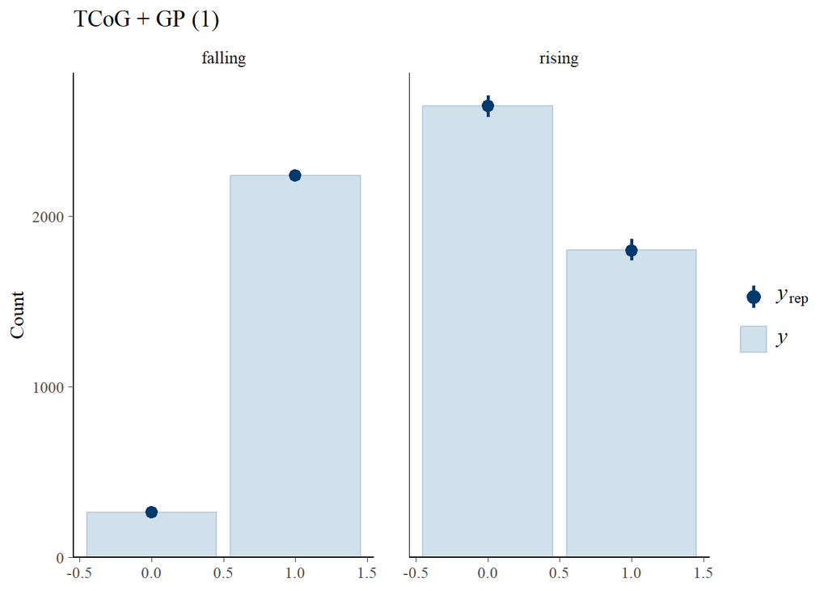

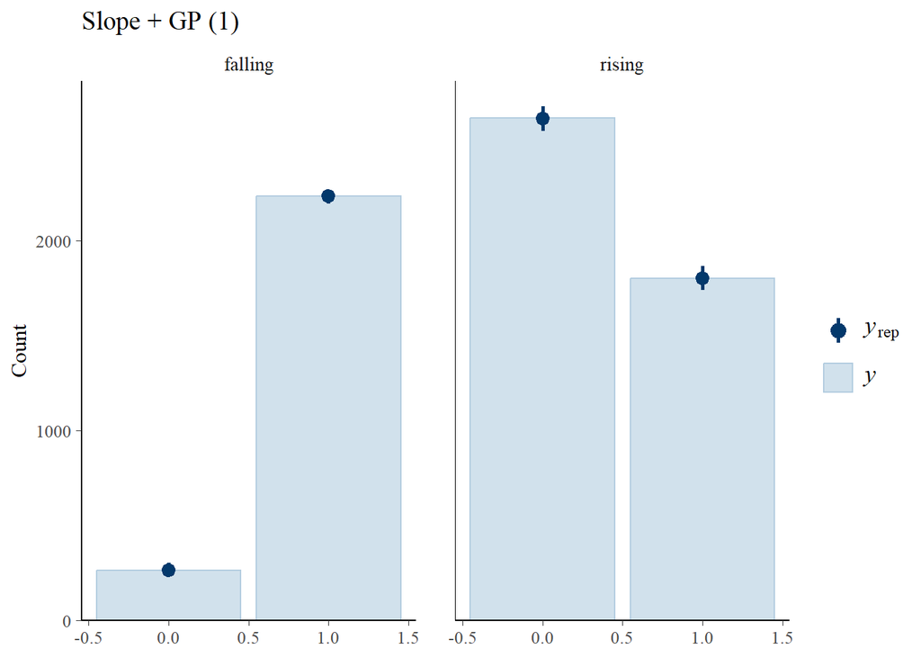

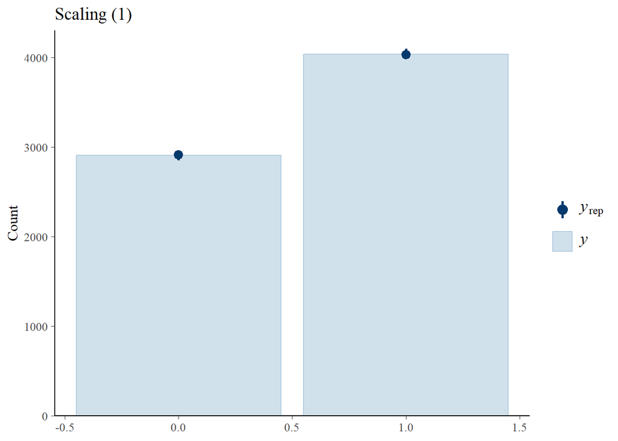

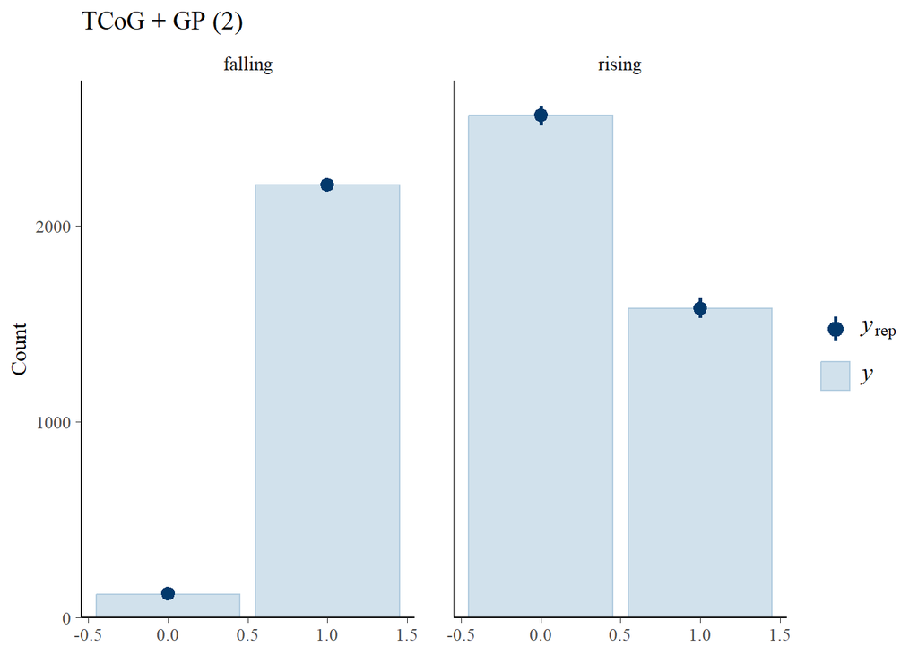

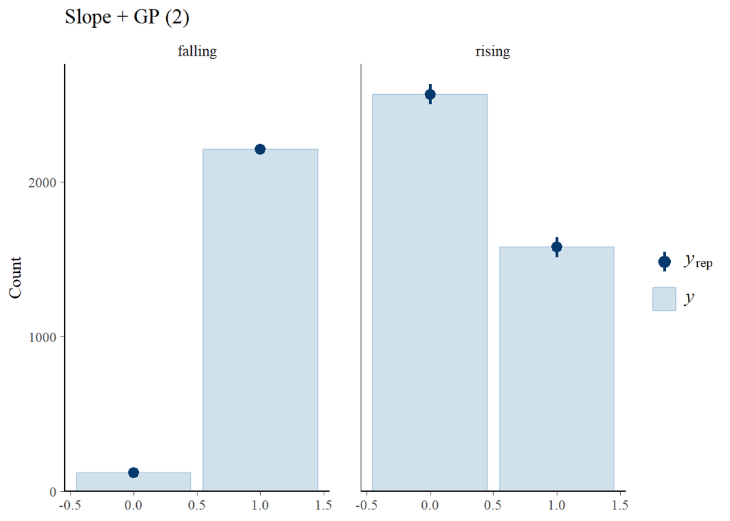

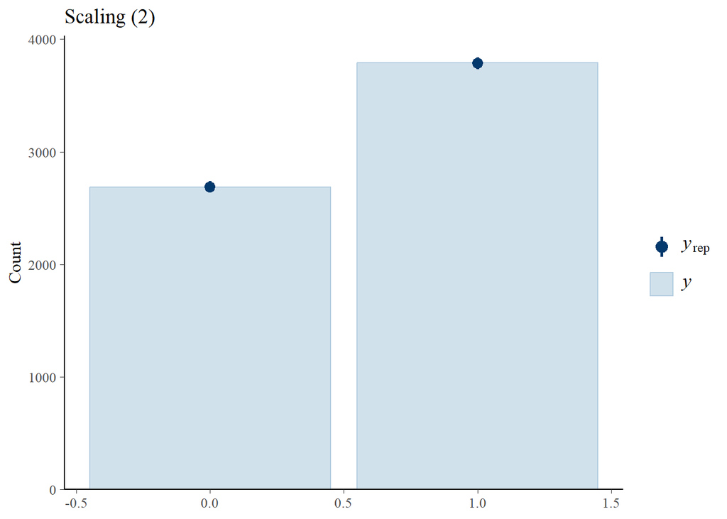

## Augmented & Scaling model: Alternate experiment

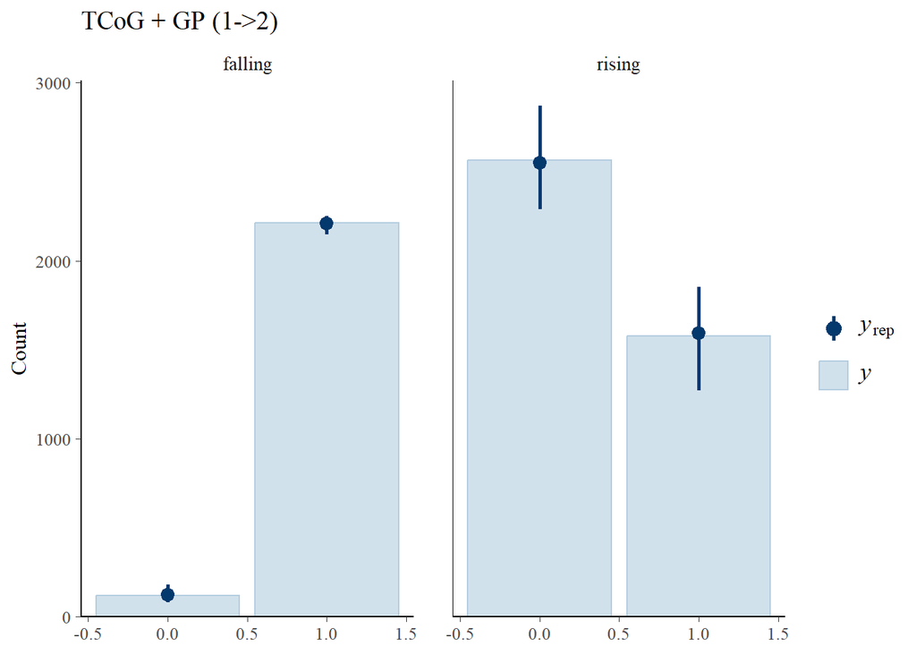

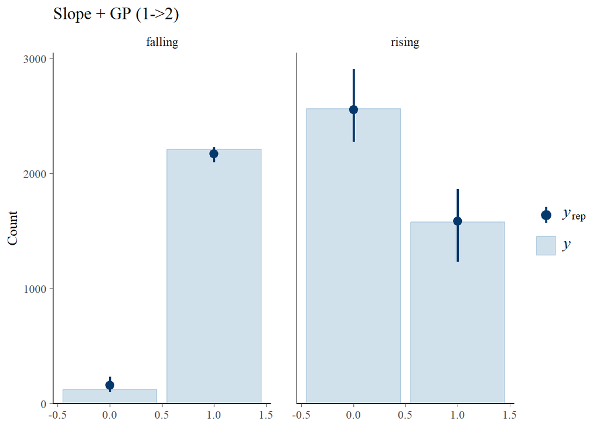

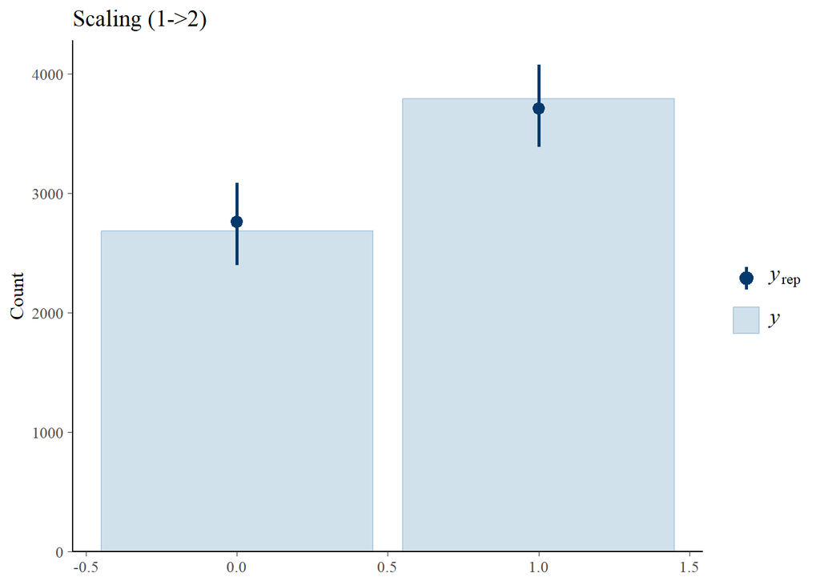

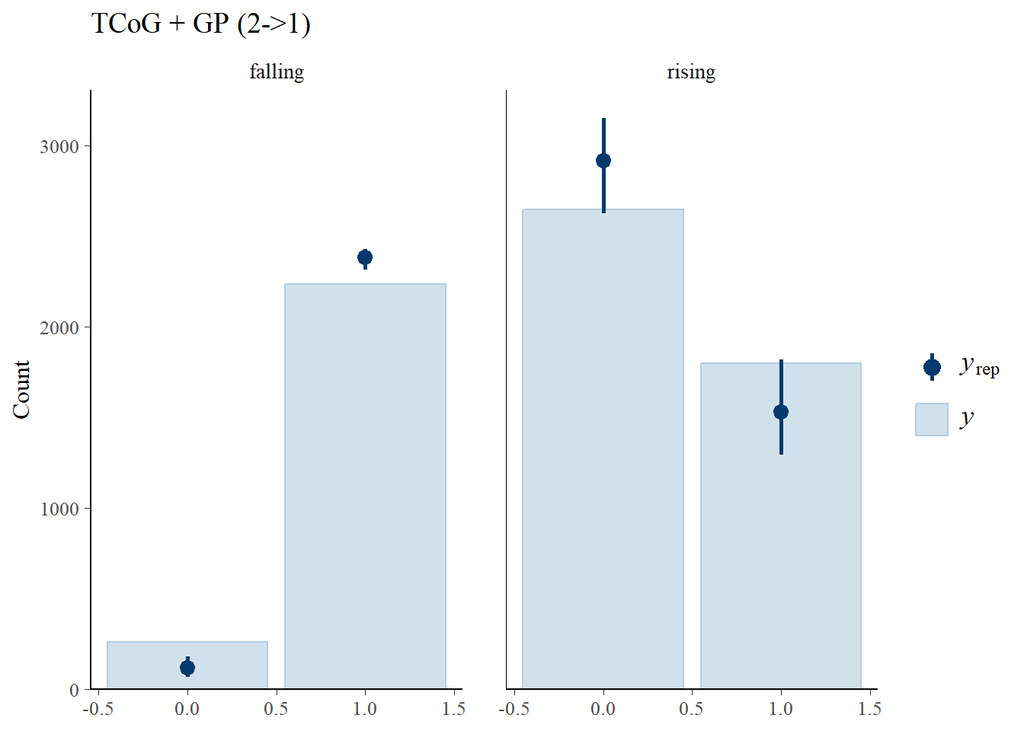

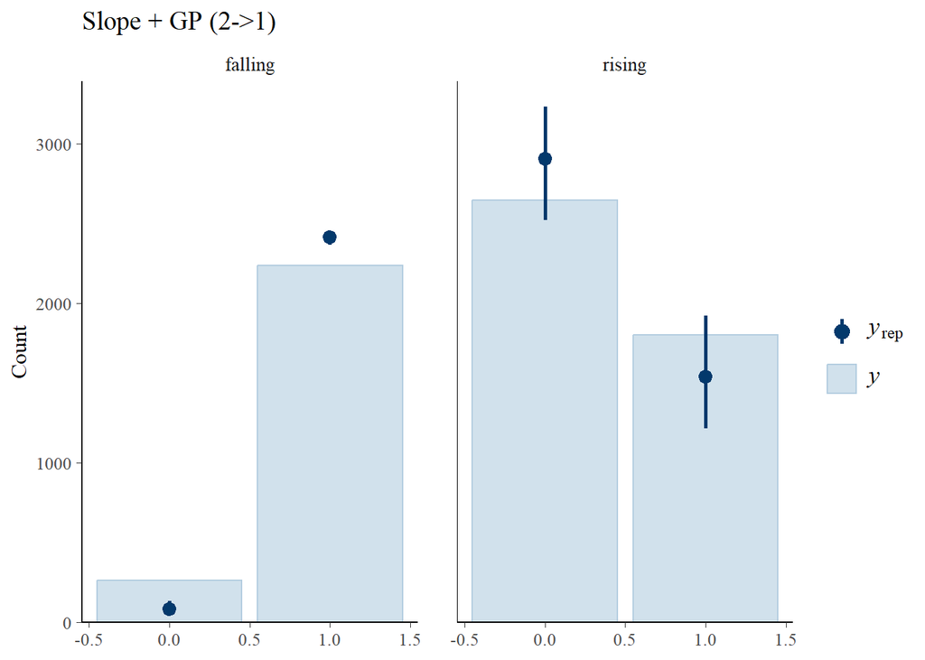

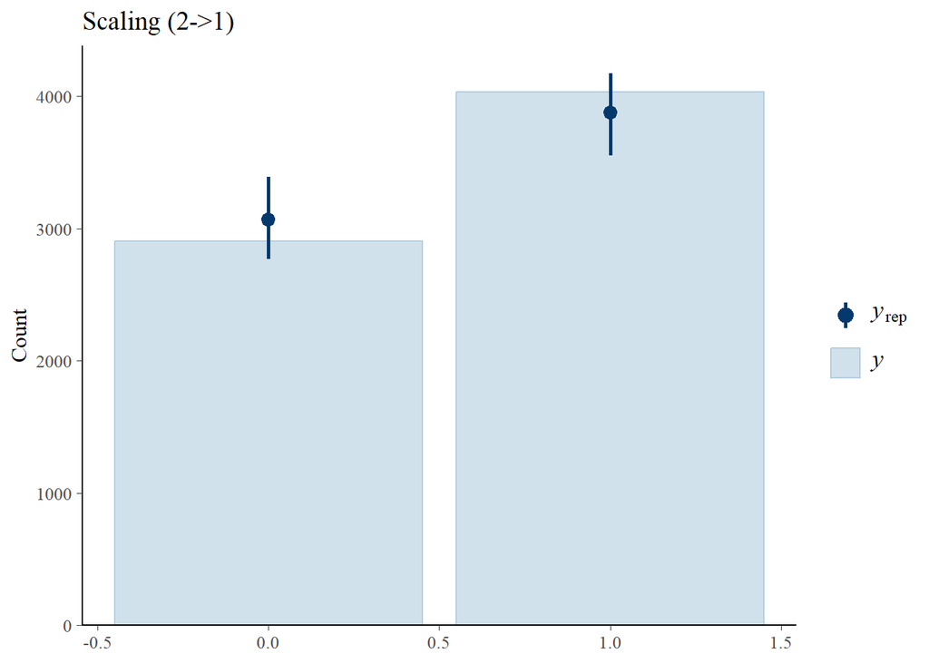

## TCoG and Slope only: Modeled data

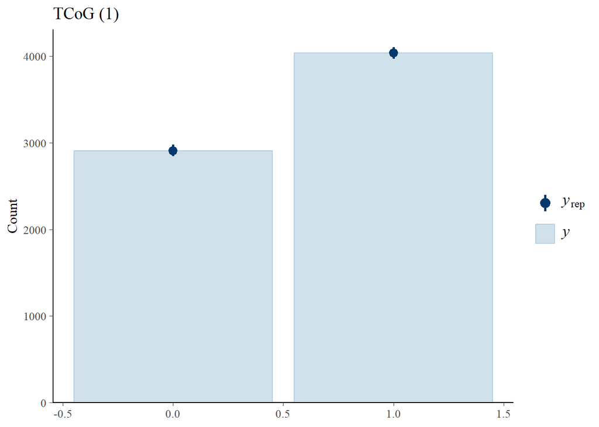

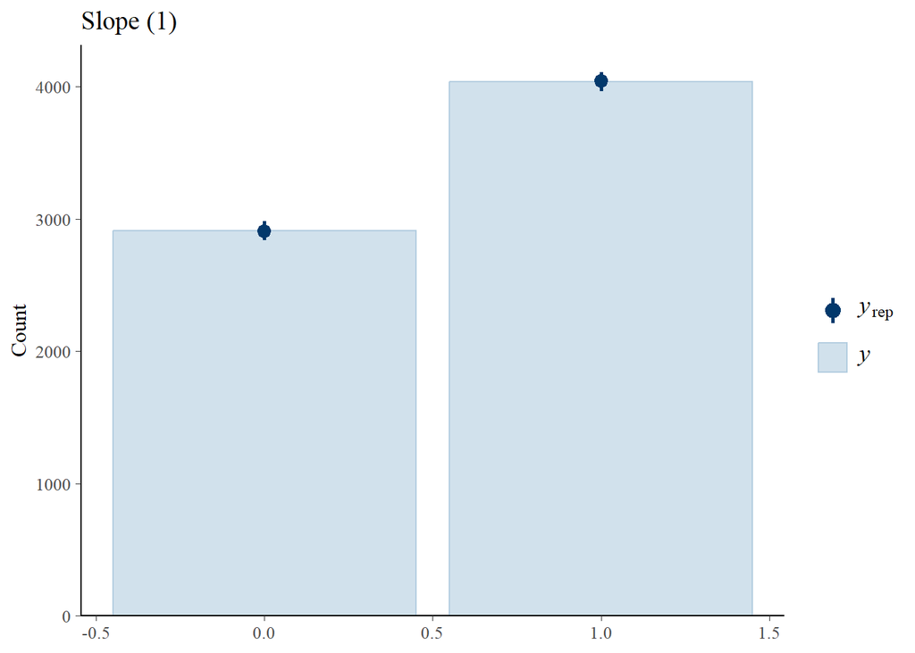

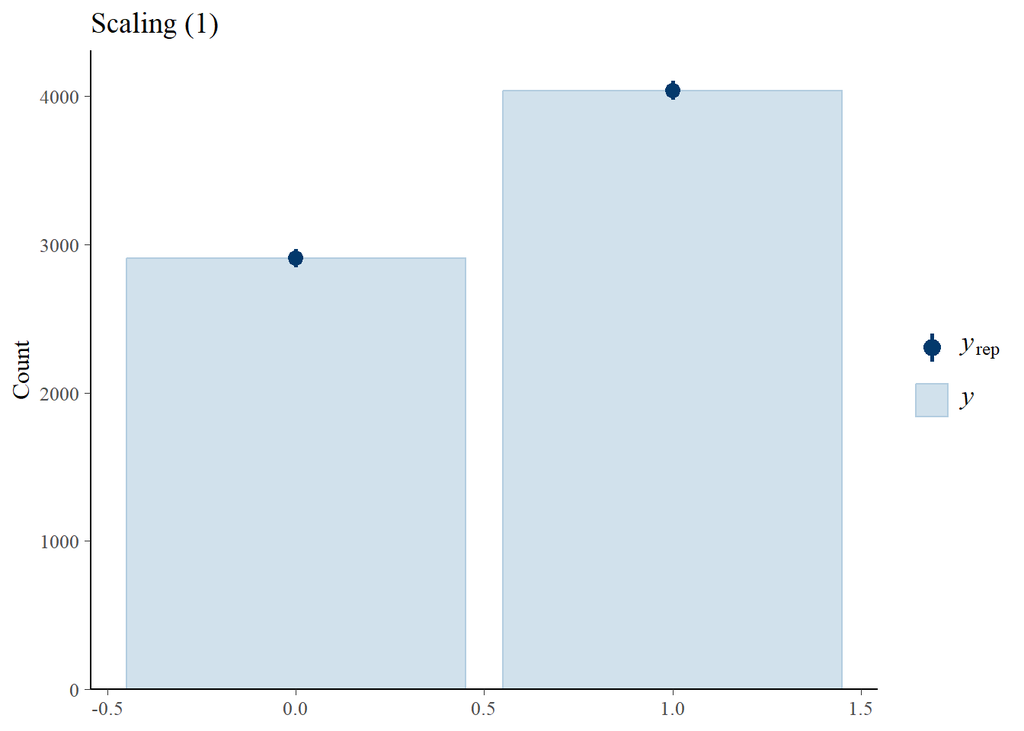

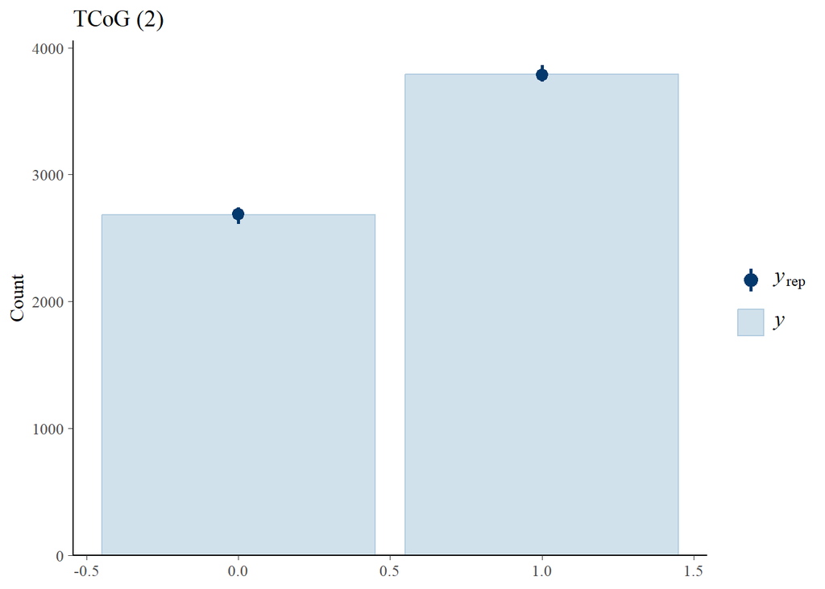

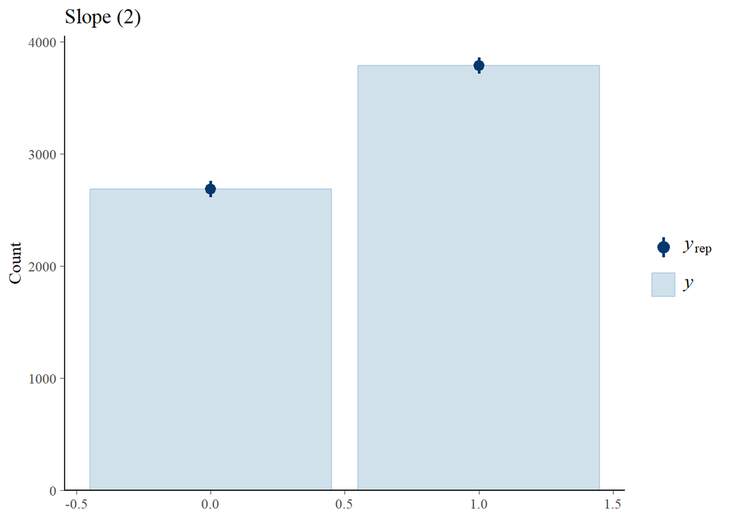

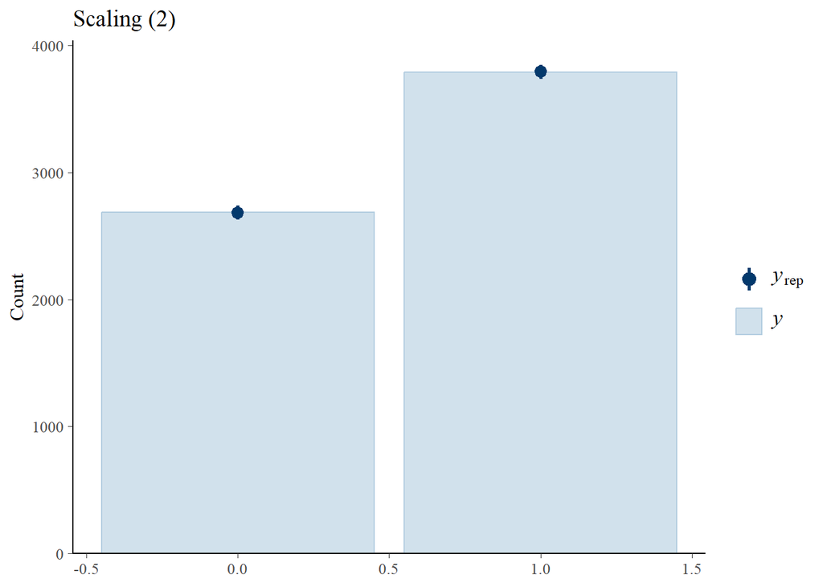

## TCoG and Slope only: Alternate experiment

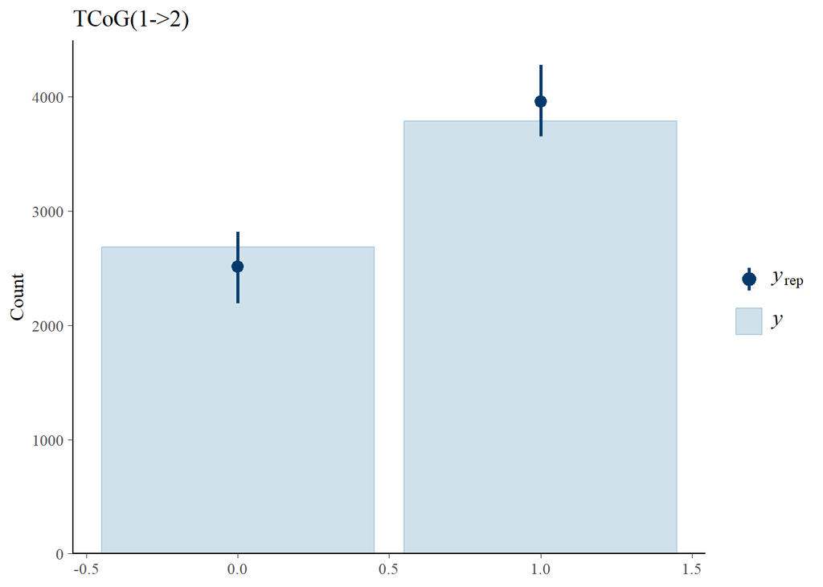

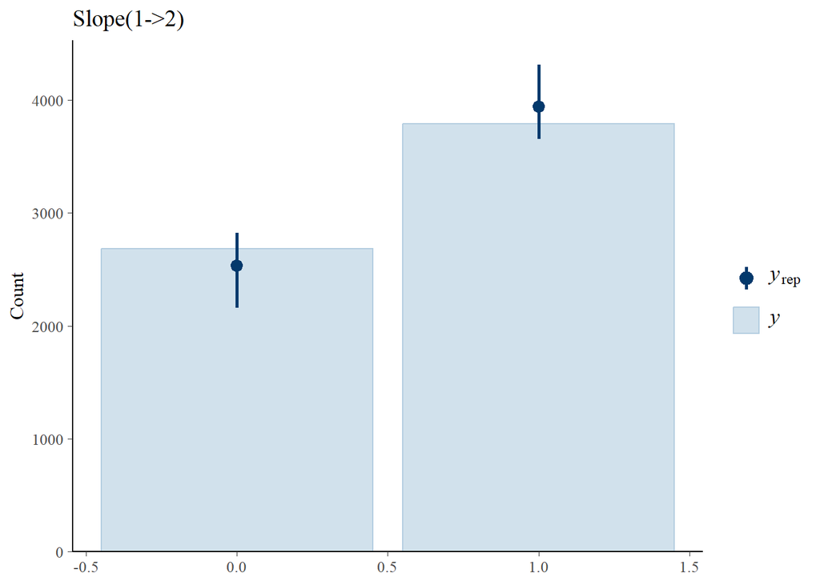

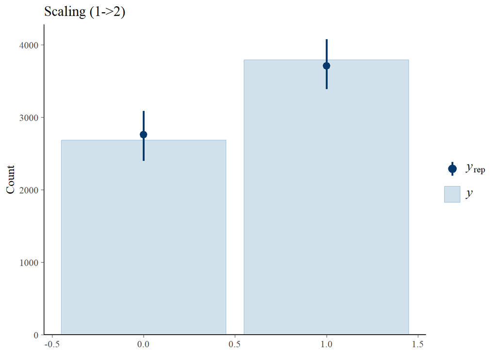

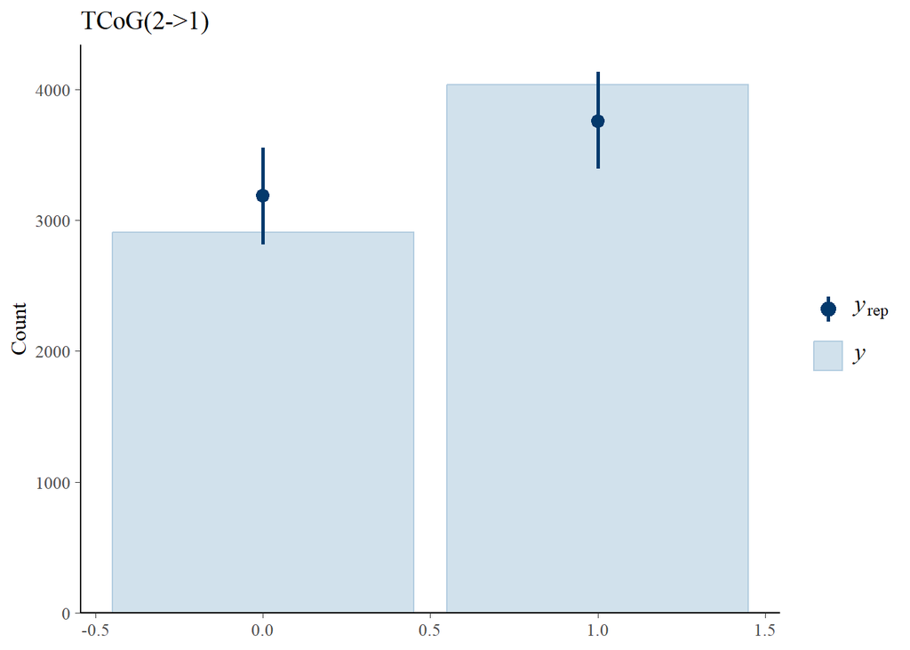

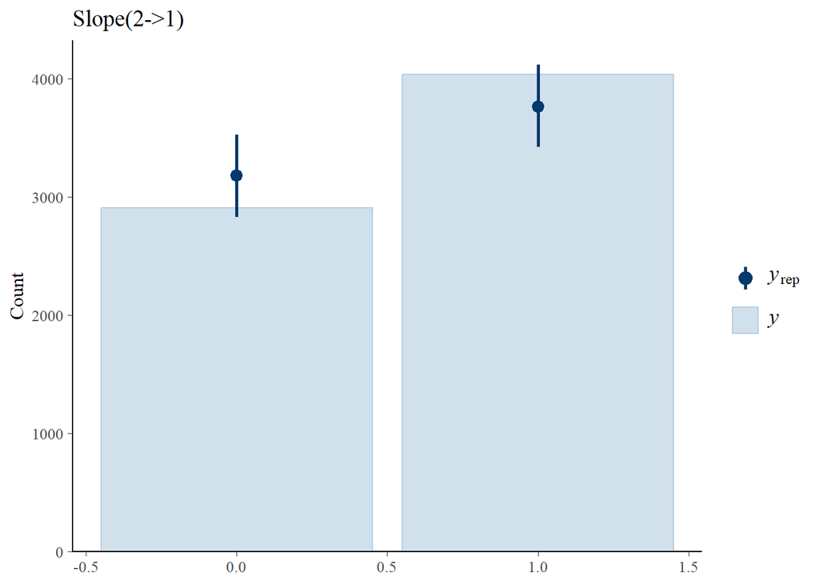

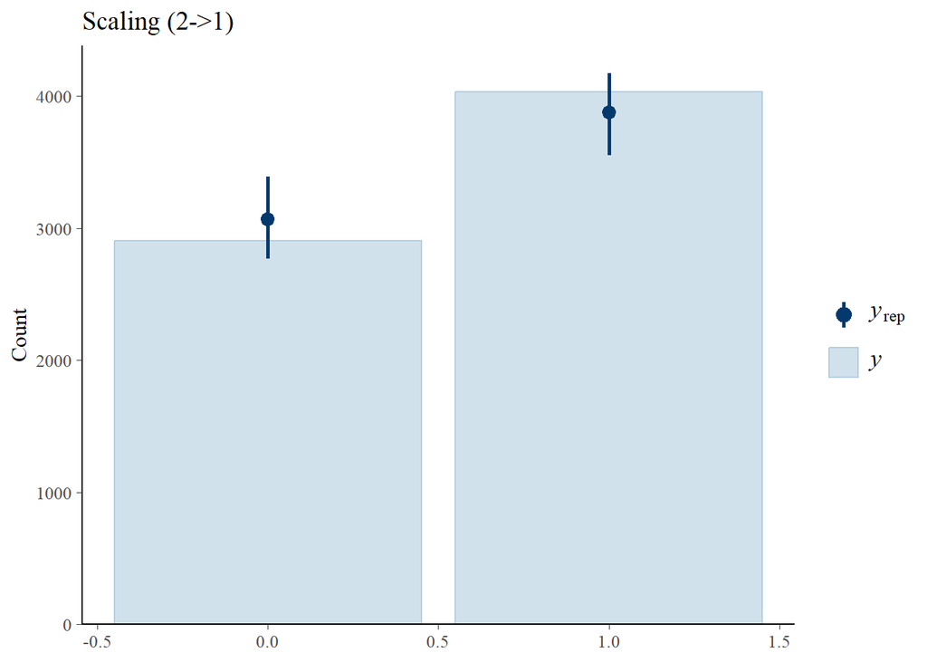

## Posterior Predictive Heatmaps

Based on the posterior predictive checks above, we can see that when trying to predict the data in the alternate experiment, the models all seem to be a little bit off. However, it is not clear whether the mistakes these models are making are all the same kind of mistakes. We know it underpredicts in some cases and overpredicts in others, but not if the “problematic” cases are the same across models. Below, I show a series of *differential heatmaps* plotting the predicted proportion of *telling* responses from each model *minus* the actual proportion from the empirical data. If the model is overpredicting the proportion of telling responses, this value will be positive; conversely, if the model underpredicts, this value will be negative. Values at or near zero mean that the model accurately generalizes to that particular combination of pitch accent and boundary tone.[^1] What we’re interested is if the pattern of the darkest values in the cells are different or the same for the different models.

```r
exp1_scaling_diffs <- get_cell_differences(exp1_scaling_reg, exp2_data)
exp1_tcog_diffs <- get_cell_differences(exp1_tcog_reg, exp2_data)
exp1_tcogonly_diffs <- get_cell_differences(exp1_tcogonly_reg, exp2_data)
exp1_slope_diffs <- get_cell_differences(exp1_slope_reg, exp2_data, 'st_diff')
exp1_slopeonly_diffs <- get_cell_differences(exp1_slopeonly_reg, exp2_data, 'st_diff')

exp2_scaling_diffs <- get_cell_differences(exp2_scaling_reg, exp1_data)
exp2_tcog_diffs <- get_cell_differences(exp2_tcog_reg, exp1_data)
exp2_tcogonly_diffs <- get_cell_differences(exp2_tcogonly_reg, exp1_data)
exp2_slope_diffs <- get_cell_differences(exp2_slope_reg, exp1_data, 'st_diff')
exp2_slopeonly_diffs <- get_cell_differences(exp2_slopeonly_reg, exp1_data, 'st_diff')

exp1_scaling_heatmap <- plot_differential_heatmap(exp1_scaling_diffs)
exp1_tcog_heatmap <- plot_differential_heatmap(exp1_tcog_diffs)
exp1_tcogonly_heatmap <- plot_differential_heatmap(exp1_tcogonly_diffs)
exp1_slope_heatmap <- plot_differential_heatmap(exp1_slope_diffs)
exp1_slopeonly_heatmap <- plot_differential_heatmap(exp1_slopeonly_diffs)

exp2_scaling_heatmap <- plot_differential_heatmap(exp2_scaling_diffs)
exp2_tcog_heatmap <- plot_differential_heatmap(exp2_tcog_diffs)
exp2_tcogonly_heatmap <- plot_differential_heatmap(exp2_tcogonly_diffs)
exp2_slope_heatmap <- plot_differential_heatmap(exp2_slope_diffs)
exp2_slopeonly_heatmap <- plot_differential_heatmap(exp2_slopeonly_diffs)
```

### Exp1 -> Exp2

In these plots, the scaling model is shown first at the top. Remember that we already know this model is implementationally the best at capturing the data in our experiments, but it is also counterintuitive. Following the scaling model I show the two TCoG models (TCoG only, then TCoG plus global pattern) and then the two slope models.

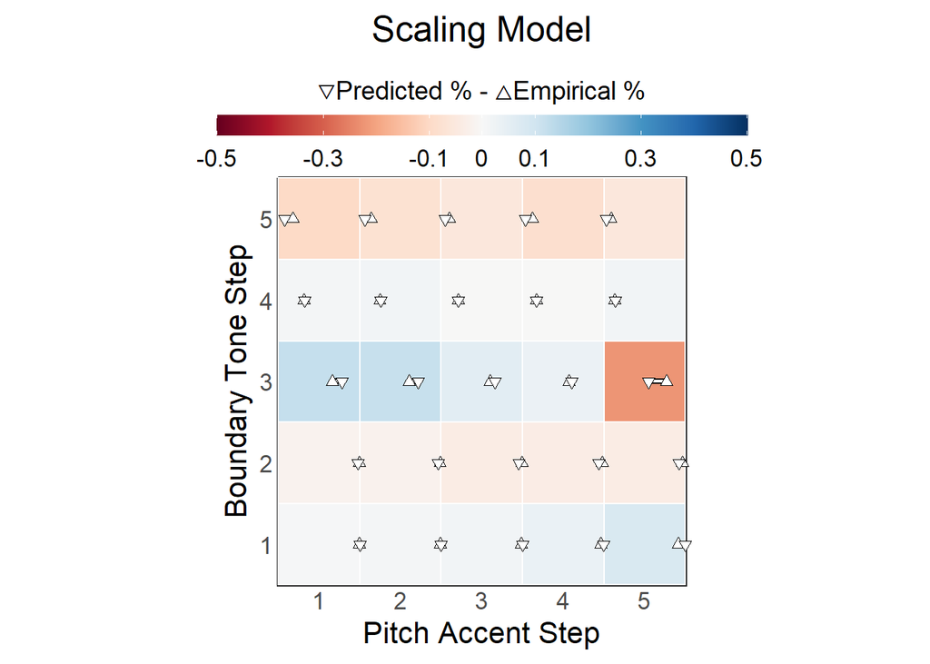

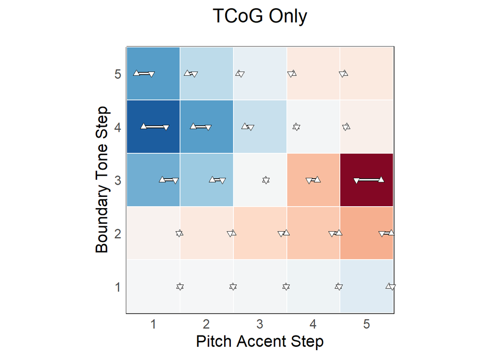

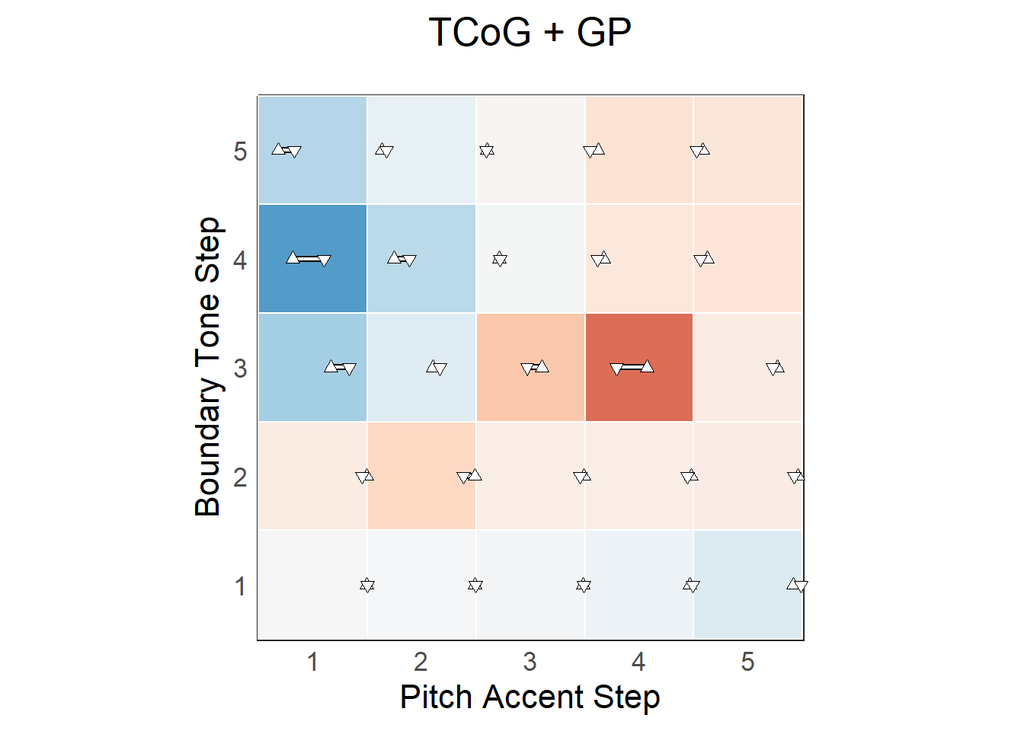

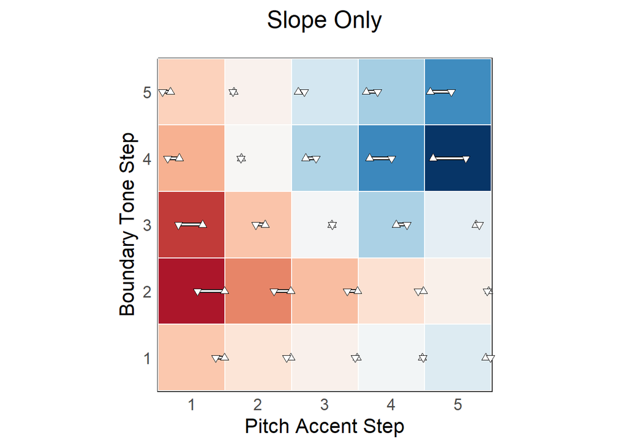

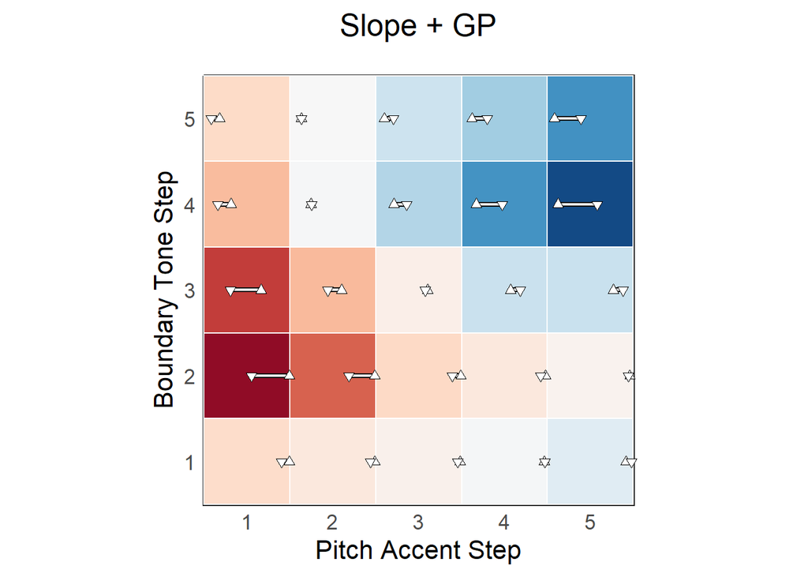